# Impacto de la vida amorosa en el ámbito académico de los alumnos de UTEC en el periodo 2022-1

### Procedimiento de limpieza

Comenzaremos realizando la lectura de la base de datos:

¿Cuantas observaciones tiene la base de datos?

```r
nrow(G1) # Observaciones
```

```
## [1] 206
```

```r
ncol(G1) # Variables
```

```
## [1] 26
```

Casos completos-incompletos:

```r
sum(complete.cases(G1)) #completos
```

```
## [1] 206
```

```r
sum(!complete.cases(G1)) #incompletos
```

```
## [1] 0
```

¿Cuántos datos faltantes y completos hay en la base de datos?

```r
sum(is.na(G1)) #incompletos
```

```
## [1] 0
```

```r
sum(!is.na(G1)) #completos.
```

```
## [1] 5356
```

El número de datos totales que tiene la base de datos:

```r
sum(is.na(G1))+sum(!is.na(G1))
```

```
## [1] 5356
```

```r
nrow(G1)*ncol (G1)
```

```
## [1] 5356
```

Reconocer las variables:

```r
names(G1)
```

```
##  [1] "Marca temporal"
##  [2] "¿Qué edad tienes hasta la fecha?"
##  [3] "¿Género?"
##  [4] "Selecciona tu carrera"
##  [5] "¿En que ciclo te encuentras actualmente?"
##  [6] "¿Cuántas relaciones amorosas tuviste hasta el 2022-2?"
##  [7] "¿Actualmente tienes una relación amorosa?"
##  [8] "¿Tu pareja y tú estudian o estudiaban en la misma universidad?"
##  [9] "¿Consideras que tu vida amorosa afectaría tu rendimiento académico? (En caso de no estar en una relación responder si crees que podría afectarte)"
## [10] "¿Tu vida amorosa ha tenido un impacto negativo en tu motivación y actitud hacia tus estudios? (En caso de no estar en una relación responder si crees que podría afectarte)"
## [11] "¿Cuáles crees que serían los principales desafíos que enfrenta tu vida amorosa y como esto repercute en lo académico? (En caso de no estar en una relación responder que crees que podría afectarte)"
## [12] "¿Cuáles son las principales formas en que te gustaría recibir apoyo de la universidad para manejar problemas de tu vida amorosa en relación con tus estudios? Selecciona todas las opciones que apliquen."
## [13] "En la escala de 0 al 10, donde 0 es \"Extremadamente mal\" y 10 es \"Extremadamente bien\", ¿Cómo crees que te va en tu vida amorosa?"
## [14] "En la escala de 0 al 10, donde 0 es \"Extremadamente mal\" y 10 es \"Extremadamente bien\", ¿Cómo crees que te va académicamente?"
## [15] "En una escala del 0 al 10, donde 0 es “Extremadamente mal” y 10 es “Extremadamente bien”, ¿Cómo definirías la relación entre tu vida amorosa y académica en este momento?"
## [16] "¿Administras tu tiempo entre tus estudios y tu relación?  (En caso de no estar en una relación, ¿Crees que podrías administrar tu tiempo)"
## [17] "¿Cuántas horas dedicas al estudio al día?"
## [18] "¿Cuántas horas pasas tiempo con tu pareja al día?  (En caso de no estar en una relación ,¿cuanto tiempo le dedicarías?)"
## [19] "¿Has faltado alguna vez a clases por salir con tu pareja? (En caso de no estar en una relación, ¿crees que de estarlo lo harías?)"
## [20] "¿Consideras que es un problema para ti manejar una relación a la par de la universidad?  (En caso de no estar en una relación crees que sería un problema para ti)"
## [21] "¿Las discusiones o conflictos con tu pareja afectan tu capacidad para concentrarte en tus estudios?  (En caso de no estar en una relación crees que te afectaría)"
## [22] "¿Sueles desconcentrarte en el móvil o en algún otro dispositivo esperando o respondiendo un mensaje de tu pareja mientras estás en clase? (En caso de no estar en una relación consideras que te desconcentrarías)"
## [23] "¿Una ruptura con tu pareja afecta cuando tienes que dar un examen?  (En caso de no estar en una relación crees que te afectaría)"
## [24] "¿Cúal fue tu promedio en el último ciclo cursado en la universidad UTEC?"
## [25] "¿Cuáles son las principales formas en que tu relación amorosa ha afectado tu rendimiento académico?"
## [26] "¿Cuáles son las principales sugerencias que tendrías para la universidad para mejorar el apoyo que brinda a los estudiantes que enfrentan problemas en su vida amorosa y académica?"
```

Cambiamos el nombre de las variables para que sean más cortas y así hacerlo más simple manejarlo

```r
library(dplyr)

G1=rename(G1,Edad='¿Qué edad tienes hasta la fecha?',Genero ='¿Género?', Carrera ='Selecciona tu carrera', Ciclo ='¿En que ciclo te encuentras actualmente?', Nrelaciones ='¿Cuántas relaciones amorosas tuviste hasta el 2022-2?', Relacion ='¿Actualmente tienes una relación amorosa?', MismaUniversidad ='¿Tu pareja y tú estudian o estudiaban en la misma universidad?', RAcademicoAfectado ='¿Consideras que tu vida amorosa afectaría tu rendimiento académico? (En caso de no estar en una relación responder si crees que podría afectarte)', INegativoMotivacion ='¿Tu vida amorosa ha tenido un impacto negativo en tu motivación y actitud hacia tus estudios? (En caso de no estar en una relación responder si crees que podría afectarte)', Desafios ='¿Cuáles crees que serían los principales desafíos que enfrenta tu vida amorosa y como esto repercute en lo académico? (En caso de no estar en una relación responder que crees que podría afectarte)', FormasDeApoyo ='¿Cuáles son las principales formas en que te gustaría recibir apoyo de la universidad para manejar problemas de tu vida amorosa en relación con tus estudios? Selecciona todas las opciones que apliquen.', VidaAmorosa ='En la escala de 0 al 10, donde 0 es \"Extremadamente mal\" y 10 es \"Extremadamente bien\", ¿Cómo crees que te va en tu vida amorosa?', VidaAcademica ='En la escala de 0 al 10, donde 0 es \"Extremadamente mal\" y 10 es \"Extremadamente bien\", ¿Cómo crees que te va académicamente?', RelacionVidaAmorosaYAcadémica ='En una escala del 0 al 10, donde 0 es “Extremadamente mal” y 10 es “Extremadamente bien”, ¿Cómo definirías la relación entre tu vida amorosa y académica en este momento?', AdministarTiempo ='¿Administras tu tiempo entre tus estudios y tu relación?  (En caso de no estar en una relación, ¿Crees que podrías administrar tu tiempo)', HEstudio ='¿Cuántas horas dedicas al estudio al día?', HPareja ='¿Cuántas horas pasas tiempo con tu pareja al día?  (En caso de no estar en una relación ,¿cuanto tiempo le dedicarías?)', FaltaClases ='¿Has faltado alguna vez a clases por salir con tu pareja? (En caso de no estar en una relación, ¿crees que de estarlo lo harías?)', RelacionYUniversidad ='¿Consideras que es un problema para ti manejar una relación a la par de la universidad?  (En caso de no estar en una relación crees que sería un problema para ti)', DiscusionesAfectaConcentracion ='¿Las discusiones o conflictos con tu pareja afectan tu capacidad para concentrarte en tus estudios?  (En caso de no estar en una relación crees que te afectaría)', Desconcentracion ='¿Sueles desconcentrarte en el móvil o en algún otro dispositivo esperando o respondiendo un mensaje de tu pareja mientras estás en clase? (En caso de no estar en una relación consideras que te desconcentrarías)', RupturaAfectaExamenes ='¿Una ruptura con tu pareja afecta cuando tienes que dar un examen?  (En caso de no estar en una relación crees que te afectaría)', Promedio ='¿Cúal fue tu promedio en el último ciclo cursado en la universidad UTEC?', FormasAfectaRendimientoAcademico ='¿Cuáles son las principales formas en que tu relación amorosa ha afectado tu rendimiento académico?',sugerencias='¿Cuáles son las principales sugerencias que tendrías para la universidad para mejorar el apoyo que brinda a los estudiantes que enfrentan problemas en su vida amorosa y académica?')
```

Usamos el comando `str` para que devuelva un resumen del tipo de variable que asumirá RStudio, al momento de leer la base de datos:

```r
str(G1)
```

```
## spc_tbl_ [206 x 26] (S3: spec_tbl_df/tbl_df/tbl/data.frame)
##  $ Marca temporal                  : chr [1:206] "4/26/2023 11:15:02" "4/26/2023 11:22:06" "4/26/2023 11:23:14" "4/26/2023 11:24:08" ...
##  $ Edad                            : num [1:206] 18 18 19 18 19 18 19 18 21 24 ...
##  $ Genero                          : chr [1:206] "Femenino" "Femenino" "Masculino" "Masculino" ...
##  $ Carrera                         : chr [1:206] "Ingeniería Indusrial" "Ingeniería Indusrial" "Ingeniería Indusrial" "Ingeniería Mecatrónica" ...
##  $ Ciclo                           : num [1:206] 4 2 5 2 4 2 2 2 4 2 ...
##  $ Nrelaciones                     : num [1:206] 1 3 4 3 2 1 2 3 5 2 ...
##  $ Relacion                        : chr [1:206] "Sí" "Sí" "Sí" "Sí" ...
##  $ MismaUniversidad                : chr [1:206] "Sí" "Sí" "Sí" "Sí" ...
##  $ RAcademicoAfectado              : chr [1:206] "Si" "No" "No" "No" ...
##  $ INegativoMotivacion             : chr [1:206] "Sí, mi vida amorosa tuvo un impacto negativo en mi motivación y actitud hacia mis estudios." "No, mi vida amorosa no ha tenido un impacto negativo en mi motivación y actitud hacia mis estudios." "No, mi vida amorosa no ha tenido un impacto negativ…
##  $ Desafios                        : chr [1:206] "Falta de tiempo, Problemas de comunicación con la pareja, Problemas de confianza o celos en la relación" "Falta de tiempo" "Problemas de comunicación con la pareja, Problemas de confianza o celos en la relación, Distracción y desconcentración" "Fa…
##  $ FormasDeApoyo                   : chr [1:206] "Consejería o terapia de pareja, Talleres o grupos de discusión sobre relaciones saludables" "Recursos en línea (por ejemplo, artículos, videos, podcasts, etc.)" "Consejería o terapia de pareja, Talleres o grupos de discusión sobre relaciones salud…
##  $ VidaAmorosa                     : num [1:206] 6 8 3 3 1 2 8 10 8 6 ...
##  $ VidaAcademica                   : num [1:206] 7 7 8 7 7 6 5 7 4 8 ...
##  $ RelacionVidaAmorosaYAcadémica   : num [1:206] 6 7 0 0 4 7 8 0 7 0 ...
##  $ AdministarTiempo                : chr [1:206] "Sí" "No" "Sí" "No" ...
##  $ HEstudio                        : num [1:206] 5.3 6 2.3 5.2 3.4 7.3 5.3 5.6 4.4 2.35 ...
##  $ HPareja                         : num [1:206] 2.1 1.2 2.1 2.1 2.1 3.5 1.3 4.1 1.2 3.1 ...
##  $ FaltaClases                     : chr [1:206] "Sí" "Sí" "Sí" "No" ...
##  $ RelacionYUniversidad            : chr [1:206] "No considero" "No considero" "No considero" "No considero" ...
##  $ DiscusionesAfectaConcentracion  : chr [1:206] "No afecta" "Sí afecta" "Sí afecta" "No afecta" ...
##  $ Desconcentracion                : chr [1:206] "Sí" "Sí" "Sí" "Sí" ...
##  $ RupturaAfectaExamenes           : chr [1:206] "No" "Sí" "Sí" "No" ...
##  $ Promedio                        : num [1:206] 16.5 15.6 17.5 17.8 15 ...
##  $ FormasAfectaRendimientoAcademico: chr [1:206] "Menor tiempo de preparación para las evaluaciones, Falta de concentración en clases, Baja participación en trab"| __truncated__ "Menor tiempo de preparación para las evaluaciones" "Falta de concentración en clases, Disminución del promedio de nota…
##  $ sugerencias                     : chr [1:206] "Bienestar estudiantil ague charlas emocional" "Seria.." "No sé no tengo :'v" "Todos los estudiantes deberian de priorizar su redimiento academico." ...
##  - attr(*, "spec")=
##   .. cols(
##   ..   `Marca temporal` = col_character(),
##   ..   `¿Qué edad tienes hasta la fecha?` = col_double(),
##   ..   `¿Género?` = col_character(),
##   ..   `Selecciona tu carrera` = col_character(),
##   ..   `¿En que ciclo te encuentras actualmente?` = col_double(),
##   ..   `¿Cuántas relaciones amorosas tuviste hasta el 2022-2?` = col_double(),
##   ..   `¿Actualmente tienes una relación amorosa?` = col_character(),
##   ..   `¿Tu pareja y tú estudian o estudiaban en la misma universidad?` = col_character(),
##   ..   `¿Consideras que tu vida amorosa afectaría tu rendimiento académico? (En caso de no estar en una relación responder si crees que podría afectarte)` = col_character(),
```

[output cut: 19 more lines]

Lo que realizaremos será una recategorización correctas de variables, debido a que al importarlas a R automáticamente generó un cambio en ciertos datos.

Cambiar la variable “Ciclo, VidaAmorosa, VidaAcadémica, RelacionVidaAmorosaYAcadémica” a categórica.

```r
G1$Ciclo = as.character(G1$Ciclo)
```

```r
G1$VidaAmorosa <- as.character(gsub(".*?([0-10]+).*", "\\1", G1$VidaAmorosa))
```

```r
G1$VidaAcademica  <-  as.character(gsub(".*?([0-10]+).*", "\\1", G1$VidaAcademica ))
```

```r
G1$RelacionVidaAmorosaYAcadémica  <- as.character(gsub(".*?([0-10]+).*", "\\1", G1$RelacionVidaAmorosaYAcadémica))
```

Cambiamos las variable “Edad, Nrelaciones” a numérica entera.

```r
G1$Edad <- as.integer(G1$Edad )
```

```r
G1$Nrelaciones <- as.integer(G1$Nrelaciones  )
```

Modificamos la variable “Promedio” a numérica.

```r
G1$Promedio <- as.numeric(G1$Promedio)
```

Entonces obtendríamos la siguiente base de datos.

```r
head(G1)
```

```
## # A tibble: 6 x 26
##   `Marca temporal`    Edad Genero    Carrera          Ciclo Nrelaciones Relacion
##   <chr>              <int> <chr>     <chr>            <chr>       <int> <chr>
## 1 4/26/2023 11:15:02    18 Femenino  Ingeniería Indu~ 4               1 Sí
## 2 4/26/2023 11:22:06    18 Femenino  Ingeniería Indu~ 2               3 Sí
## 3 4/26/2023 11:23:14    19 Masculino Ingeniería Indu~ 5               4 Sí
## 4 4/26/2023 11:24:08    18 Masculino Ingeniería Meca~ 2               3 Sí
## 5 4/26/2023 11:25:21    19 Masculino Ingeniería Indu~ 4               2 Sí
## 6 4/26/2023 11:26:06    18 Femenino  Ingeniería Indu~ 2               1 Sí
## # i 19 more variables: MismaUniversidad <chr>, RAcademicoAfectado <chr>,
## #   INegativoMotivacion <chr>, Desafios <chr>, FormasDeApoyo <chr>,
## #   VidaAmorosa <chr>, VidaAcademica <chr>,
## #   RelacionVidaAmorosaYAcadémica <chr>, AdministarTiempo <chr>,
## #   HEstudio <dbl>, HPareja <dbl>, FaltaClases <chr>,
## #   RelacionYUniversidad <chr>, DiscusionesAfectaConcentracion <chr>,
## #   Desconcentracion <chr>, RupturaAfectaExamenes <chr>, Promedio <dbl>, ...
```

Observamos que en la base de datos se encuentran columnas que no serán de utilidad, como lo son “la marca temporal” y “sugerencias”. Por el cual eliminaremos aquellas columnas.

```r
G1 %>% select(-`Marca temporal`, -sugerencias) -> G1
```

Encontramos respuestas incoherentes en la variable “Promedio” y “RAcademicoAfectado”, por ello reordenaremos las respuestas brindadas.

```r
unique(G1$Promedio)
```

```
##  [1]   16.50   15.55   17.50   17.80   15.00   14.55   14.30   14.29   13.50
## [10]   17.60   16.15   14.15   16.90   10.50   14.50  150.00   17.90   13.78
## [19]   16.00   17.20   14.80   15.43   14.00   14.85 1455.00 1255.00   12.83
## [28]   15.60   15.40   15.10   13.56   18.00   12.00  155.00   18.30   15.50
## [37]   16.64   17.65   15.15   12.80   13.75   14.60   17.55   11.90   15.86
## [46]   18.15   13.40   16.88   16.80   13.52   14.78   12.50   17.16   18.50
## [55]   14.20   16.70   16.25 1355.00   13.00   16.40   14.70   12.34   16.87
## [64]   16.57   13.57   11.43   15.65   17.77   16.30   13.80   15.70   18.75
## [73]   15.76   12.60   16.75   13.48   11.45   12.65   15.75   12.41   13.90
## [82]   17.00   20.00   16.79   11.00   19.99   14.43   15.85   11.50   11.55
## [91]   13.55   13.77   13.88   16.65   14.58   13.58   13.59   15.77
```

```r
unique(G1$RAcademicoAfectado)
```

```
## [1] "Si" "No" "Sí"
```

```r
G1 %>% mutate(Promedio =
        ifelse(Promedio == "1455", "14.55",
        ifelse(Promedio == "150", "15.00",
        ifelse(Promedio == "1255", "12.55",
        ifelse(Promedio == "155", "15.50",
        ifelse(Promedio == "19.99", "18",
        ifelse(Promedio=="20","18",
        ifelse(Promedio=="1355","13.55",Promedio)))))))) -> G1

#Modificamos la variable "promedio" a numérica
G1$Promedio <-as.numeric(G1$Promedio)
```

```r
G1 %>% mutate(RAcademicoAfectado =
        ifelse(RAcademicoAfectado == "Si", "Sí",
        RAcademicoAfectado)) -> G1
```

Cambiamos las respuestas de la variable “INegativoMotivación” para hacerla más practica y ordenada al elaborar tablas.

```r
G1 %>% mutate(INegativoMotivacion=
        ifelse(INegativoMotivacion == "Sí, mi vida amorosa tuvo un impacto negativo en mi motivación y actitud hacia mis estudios.", "Sí",ifelse(INegativoMotivacion =="No, mi vida amorosa no ha tenido un impacto negativo en mi motivación y actitud hacia mis estudios.","No",INegativoMotivacion)))->G1
```

Al usar la función `summary` para la variable “HEstudio y HPareja” observamos que el máximo de las respuestas brindadas fue 12.00 horas.

```r
summary(G1$HEstudio)
```

```
##    Min. 1st Qu.  Median    Mean 3rd Qu.    Max.
##   1.200   2.300   3.400   3.857   5.275  12.000
```

```r
summary(G1$HPareja)
```

```
##    Min. 1st Qu.  Median    Mean 3rd Qu.    Max.
##   0.000   2.100   2.300   2.551   3.100  12.000
```

Observaremos cuantas fueron las personas que pusieron 12.00 horas

```r
G1 %>% filter(HEstudio>=12 | HPareja>=12)
```

```
## # A tibble: 2 x 24
##    Edad Genero    Carrera            Ciclo Nrelaciones Relacion MismaUniversidad
##   <int> <chr>     <chr>              <chr>       <int> <chr>    <chr>
## 1    20 Masculino Ingeniería Mecáni~ 4               1 Sí       No
## 2    22 Femenino  Bioingeniería      3               1 Sí       No
## # i 17 more variables: RAcademicoAfectado <chr>, INegativoMotivacion <chr>,
## #   Desafios <chr>, FormasDeApoyo <chr>, VidaAmorosa <chr>,
## #   VidaAcademica <chr>, RelacionVidaAmorosaYAcadémica <chr>,
## #   AdministarTiempo <chr>, HEstudio <dbl>, HPareja <dbl>, FaltaClases <chr>,
## #   RelacionYUniversidad <chr>, DiscusionesAfectaConcentracion <chr>,
## #   Desconcentracion <chr>, RupturaAfectaExamenes <chr>, Promedio <dbl>,
## #   FormasAfectaRendimientoAcademico <chr>
```

Encontramos 2 datos que no serán viables para el estudio, por ello los eliminamos

```r
G1=G1[-36,] #Eliminamos fila 36 y 124
G1=G1[-124,]
```

Volveremos a usar el comando `filter` para corroborar que se hayan eliminado

```r
G1 %>% filter(HEstudio>=12 | HPareja>=12)
```

```
## # A tibble: 0 x 24
## # i 24 variables: Edad <int>, Genero <chr>, Carrera <chr>, Ciclo <chr>,
## #   Nrelaciones <int>, Relacion <chr>, MismaUniversidad <chr>,
## #   RAcademicoAfectado <chr>, INegativoMotivacion <chr>, Desafios <chr>,
## #   FormasDeApoyo <chr>, VidaAmorosa <chr>, VidaAcademica <chr>,
## #   RelacionVidaAmorosaYAcadémica <chr>, AdministarTiempo <chr>,
## #   HEstudio <dbl>, HPareja <dbl>, FaltaClases <chr>,
## #   RelacionYUniversidad <chr>, DiscusionesAfectaConcentracion <chr>, ...
```

Después de haber eliminado las 2 filas innecesarias, ahora observamos la cantidad de datos completos

```r
sum(!is.na(G1))
```

```
## [1] 4896
```

Comprobamos si hay datos faltantes:

```r
sum(is.na(G1))
```

```
## [1] 0
```

Verificación de la cantidad de las observaciones para comprobar que se encuentre dentro del rango superior a 150:

```r
nrow(G1) #Empezamos con 206 casos y finalizamos con 204 casos
```

```
## [1] 204
```

Verificación de la cantidad de variables:

```r
ncol(G1) #Empezamos con 26 variables y finalizamos con 24 variables
```

```
## [1] 24
```

Luego de la limpieza de datos pasamos de tener 26 variables a 24 y de 206 casos a 204.

# **Análisis descriptivo**

## Descriptores numéricos

Para la realización de los descriptores numéricos consideramos tomar las variables más relevantes que tendrán un impacto sobre nuestra investigación.

```r
Mode(factor(G1$Ciclo,order=TRUE))
```

```
## [1] 2
## attr(,"freq")
## [1] 72
## Levels: 2 < 3 < 4 < 5 < 6 < 7 < 8 < 9
```

Al sacar la moda de la variable “ciclo” nos da como resultado 2 siendo este número el que se repite con mayor frecuencia (72), es decir, que la mayoría de entrevistados fueron del 2do ciclo.

**Vida Amorosa:** mediana

```r
Median(factor(G1$VidaAmorosa,order=TRUE))
```

```
## [1] 4
## Levels: 0 < 1 < 10 < 2 < 3 < 4 < 5 < 6 < 7 < 8 < 9
```

Nos da como resultado 4 siendo este número intermedio del grupo; lo cual concluimos también que el 50% de alumnos no se encuentra bien en su relación amorosa, ya que está por debajo del nivel “5”.

**Vida Académica:** mediana

```r
Median(factor(G1$VidaAcademica,order=TRUE))
```

```
## [1] 6
## Levels: 0 < 1 < 10 < 2 < 3 < 4 < 5 < 6 < 7 < 8 < 9
```

Nos da como resultado 6 siendo este número intermedio del grupo; lo cual concluimos también que el 50% de alumnos de UTEC se encuentra bien en sus estudios, ya que está por encima del nivel “5”.

**Relación vida amorosa y académica:** mediana

```r
Median(factor(G1$RelacionVidaAmorosaYAcadémica,order=TRUE))
```

```
## [1] 5
## Levels: 0 < 1 < 10 < 2 < 3 < 4 < 5 < 6 < 7 < 8 < 9
```

El 50% de los estudiantes de UTEC considera que la relación entre su vida académica y amorosa es menor a 5. Es así como concluimos que gran parte de los alumnos no están sobrellevando del todo bien su vida académica con su relación.

**Promedio:** mediana

```r
Median(G1$Promedio)
```

```
## [1] 14.55
```

El 50% de los estudiantes tiene un promedio menor de 14.55. Deducimos que los alumnos están teniendo un bajo nivel académico a partir de sus relaciones ya que todos los encuestados tienen una relación amorosa.

**Carrera:** moda

```r
Mode(G1$Carrera)
```

```
## [1] "Ingeniería Indusrial"
## attr(,"freq")
## [1] 58
```

Hay una mayor frecuencia de estudiantes (58) de la carrera de Ingeniería industrial participaron en la encuesta.

**Desafíos que enfrenta en su vida amorosa:** moda

```r
Mode(G1$Desafios)
```

```
## [1] "Falta de tiempo"
## attr(,"freq")
## [1] 57
```

Los principales desafíos que enfrentan los estudiantes de UTEC en su vida amorosa y que repercute en sus estudios es FALTA DE TIEMPO, concluimos de esto que los alumnos no están organizando correctamente sus horarios de pareja y esto repercute negativamente en sus estudio.

**Número de relaciones:** moda

```r
Mode(G1$Nrelaciones)
```

```
## [1] 1
## attr(,"freq")
## [1] 58
```

La mayoría de estudiantes han tenido al menos una relación amorosa hasta el ciclo 2022-2.

**Formas de apoyo que buscan de la universidad:** moda

```r
Mode(G1$FormasDeApoyo)
```

```
## [1] "Recursos en línea (por ejemplo, artículos, videos, podcasts, etc.)"
## [2] "Talleres o grupos de discusión sobre relaciones saludables"
## attr(,"freq")
## [1] 53
```

Los estudiantes les gustaría contar con recursos online y talleres dirigidos a relaciones saludables para poder sobrellevar mejor los problemas que puedan tener con su pareja.

**Falta a clases por salir con la pareja:** moda

```r
Mode(G1$FaltaClases)
```

```
## [1] "Sí"
## attr(,"freq")
## [1] 144
```

Al rededor del 70% de estudiantes faltaron a clases al menos una vez por salir con su pareja. Con esto volvemos a confirmar que los estudiantes no están organizando correctamente sus horarios.

**Problema manejar una relación a la par de la universidad:** moda

```r
Mode(G1$RelacionYUniversidad)
```

```
## [1] "Sí considero"
## attr(,"freq")
## [1] 153
```

Una cantidad de 153 estudiantes que representa más del 70% sí considera que es un problema para ellos manejar una relación a la par de la universidad.Esto nos indicaría que la relación amorosa si tiene un impacto en sus estudios.

**Discusiones con la pareja afectan concentración en los estudios:** moda

```r
Mode(G1$DiscusionesAfectaConcentracion)
```

```
## [1] "Sí afecta"
## attr(,"freq")
## [1] 145
```

Al rededor del 70% de los estudiantes considera que las discusiones afectan su desempeño académico ya que no pueden concentrarse en clases.

**Desconcentración en clases por la pareja:** moda

```r
Mode(G1$Desconcentracion)
```

```
## [1] "Sí"
## attr(,"freq")
## [1] 196
```

196 estudiantes de UTEC que representa al rededor del 90% suelen distraerse en el móvil para responder a su pareja mientras están en clases. Esto demuestra que tienen un problema de limitar el tiempo que le dedican a su pareja.

**Horas de estudio:** media

```r
round(Mean(G1$HEstudio),2)
```

```
## [1] 3.83
```

Los estudiantes se dedican al estudio fuera de la universidad un promedio de 3 horas y 80 minutos. Según nuestra encuesta antes del punto es horas y después de ello son minutos.

**Horas de pareja:** media

```r
round(Mean(G1$HPareja),2)
```

```
## [1] 2.5
```

Los estudiantes pasan tiempo con sus parejas un promedio de 2 horas y 50 minutos al día sin contar las horas que se mantienen en contacto por el móvil.

## Descriptores gráficos

#### **Gráfico de mosaico 1**

Todos los estudiantes de la muestra se encuentran en una relación, donde la gran mayoría considera que sí es un inconveniente manejar una relación amorosa a la par de la universidad.

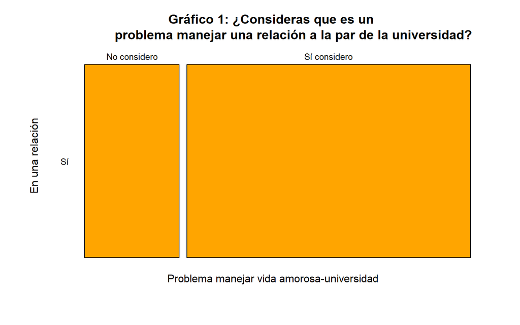

#### **Gráfico de sectores 1**

Tabla de doble entrada: Tenemos que del género femenino son 94 personas con un 46.08%, del género masculino 109 con un 53.43% y no binario solo 1 persona con el 0.49%. Sumando un total de 204 personas que conforman el 100%.

```
##
##  Tabla de frecuencias y porcentajes por género
```

```
##            Cantidad Porcentaje
## Femenino         94      46.08
## Masculino       109      53.43
## No binario        1       0.49
```

Este diagrama de sectores nos ayuda a visualizar mejor el porcentaje que hemos hallado en la tabla anterior.Observamos una mayor participación del género masculino y mínimo del no binario.

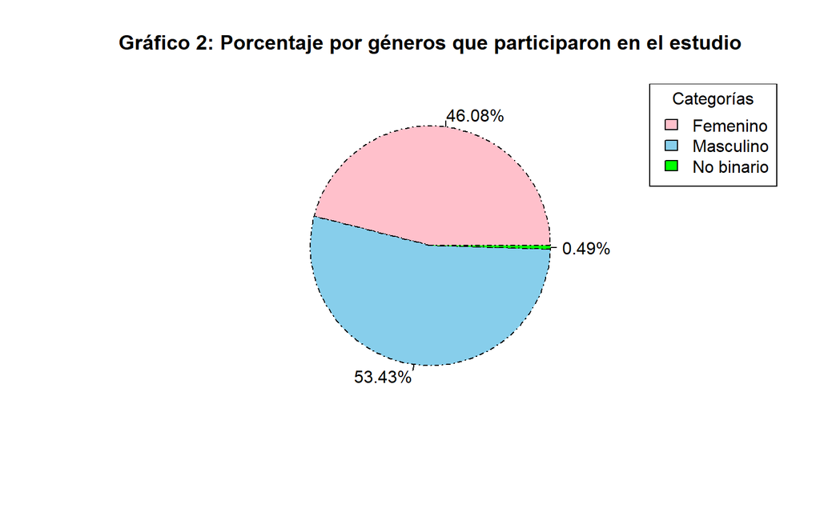

#### **Tabla 1**

Tabla de dos variables (discreta-nominal): Tenemos que del género femenino son un total de 94 estudiantes y que con mayor frecuencia 36 de ellas tuvieron 1 relación, 22 de ellas tuvieron 3 relaciones. Del género masculino son un total de 109 estudiantes y con mayor frecuencia 27 de ellos tuvieron 4 relaciones, 26 de ellos tuvieron 3 relaciones, considerando hasta el ciclo 2022-2.

```
##
##  Tabla 1: Número de relaciones de los estudiantes por género
```

```
##
##       Femenino Masculino No binario Sum
##   1         36        22          0  58
##   2         20        17          0  37
##   3         22        26          0  48
##   4          7        27          1  35
##   5          6        11          0  17
##   6          2         4          0   6
##   7          0         1          0   1
##   8          1         0          0   1
##   9          0         1          0   1
##   Sum       94       109          1 204
```

#### **Tabla 2**

Tabla simple (nominal): 142 estudiantes de UTEC no logran administrar su tiempo entre el estudio y su relación amorosa, formando así el 69.61% del total.

```
##
##  Tabla 2: Porcentaje de alumnos que administran su tiempo entre el estudio y su relación
```

```
##    Cantidad Porcentaje
## No      142      69.61
## Sí       62      30.39
```

#### **Gráfico plot 1**

Podemos inferir que los que pasan menos cantidad de horas con su pareja, tienden a tener promedios más altos en la universidad a comparación de los que pueden llegar a pasar más de tres horas con la pareja en el período académico 2022-2.

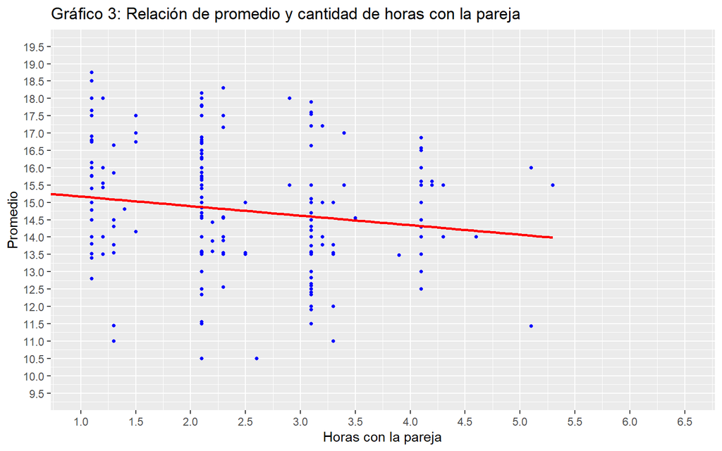

#### **Gráfico de sectores 2**

Un porcentaje de 69.61 % de estudiantes de UTEC no logran administra su tiempo entre sus estudios y su relación de pareja, mientras que un 30.39% si logra administrar su tiempo.

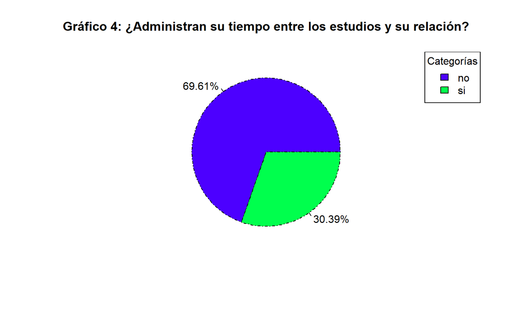

#### **Tabla 3**

```
##
##  Tabla 3: Cantidad de relaciones hasta el 2022-2 por ciclo
```

```
##
##         2   3   4   5   6   7   8   9 Sum
##   1    26   8  11   5   3   1   3   1  58
##   2    16   6   6   1   3   1   3   1  37
##   3    23   5   9   6   2   2   1   0  48
##   4     2   0   2   5  21   4   1   0  35
##   5     2   2   5   3   4   1   0   0  17
##   6     2   0   1   1   2   0   0   0   6
##   7     1   0   0   0   0   0   0   0   1
##   8     0   0   1   0   0   0   0   0   1
##   9     0   0   0   0   0   0   1   0   1
##   Sum  72  21  35  21  35   9   9   2 204
```

#### **Tabla 4**

Tabla de doble entrada (discreta): En el eje vertical izquierda está edades / En el eje horizontal superior cantidad de relaciones. 5 estudiantes de 17 años tuvieron 1 relación siendo esta la edad menor, por otro lado considerando la edad mayor que es de 24 años solo 1 estudiante tuvo 3 relaciones.

```
##
##  Tabla 4: Cantidad de relaciones hasta el 2022-2 por edad
```

```
##
##         1   2   3   4   5   6   7   8   9 Sum
##   17    5   1   2   1   1   2   0   0   0  12
##   18   19  13  15   2   3   0   1   0   1  54
##   19   15  13   6   3   3   1   0   1   0  42
##   20   13   2  11   0   2   1   0   0   0  29
##   21    2   5   2   2   1   0   0   0   0  12
##   22    3   1   9  14   4   0   0   0   0  31
##   23    1   1   2  13   3   2   0   0   0  22
##   24    0   1   1   0   0   0   0   0   0   2
##   Sum  58  37  48  35  17   6   1   1   1 204
```

#### **Tabla 5**

Tabla de doble entrada (discreta-nominal): Un dato relevante es que hay 54 estudiantes de 18 años que se encuentran en una relación, mientras que 2 estudiantes de 24 años se encuentran en una relación.

```
##
##  Tabla 5: Estudiantes en una relación por edad
```

```
##
##        Sí Sum
##   17   12  12
##   18   54  54
##   19   42  42
##   20   29  29
##   21   12  12
##   22   31  31
##   23   22  22
##   24    2   2
##   Sum 204 204
```

#### **Gráfico de barras 1**

La mayoría de alumnos han tenido 1 relación, siguiéndole 3 relaciones. En comparación hay un parecido entre 2 y 4 relaciones por cantidad de alumnos, y lo menos común es que los alumnos hayan tenido 7, 8 y 9 parejas en el ciclo 2022-2.

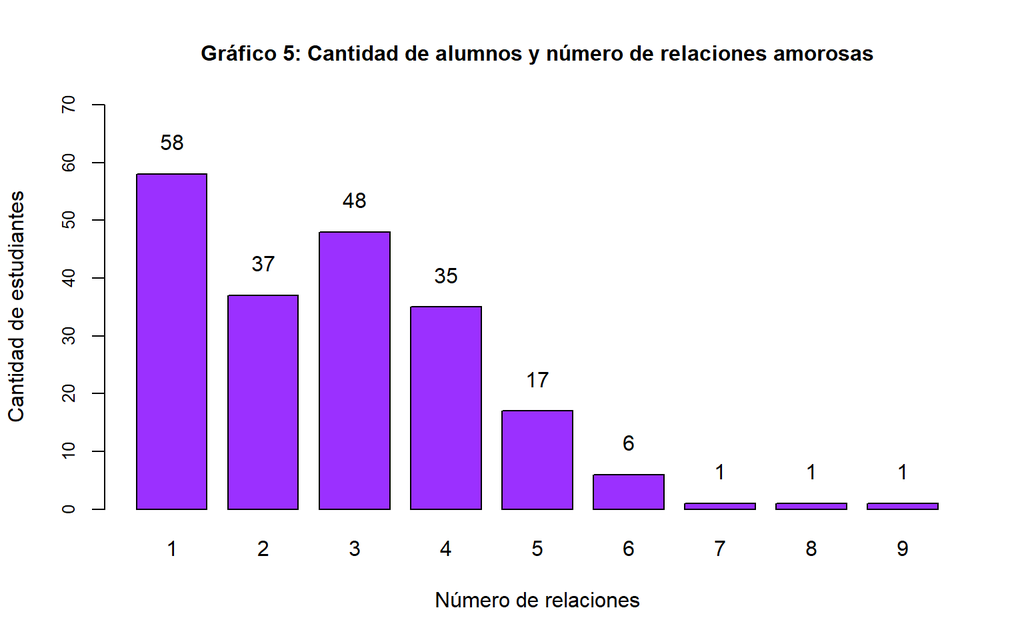

#### **Gráfico de barras 2**

La mayoría de estudiantes encuestados, como se muestra en el eje vertical izquierda [0-150] les a afecta una ruptura con su pareja en tiempos de exámenes de la universidad.

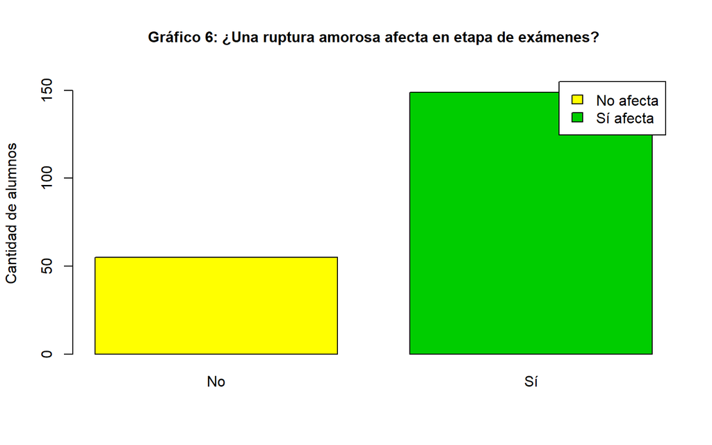

#### **Gráfico de mosaico 2**

Gran cantidad de estudiantes femenino y masculino (eje horizontal superior) faltaron a clases al menos una vez para salir con su pareja, como se demuestra con el color morado a comparación del anaranjado. También observamos que hay una mínima diferencia en cuanto al porcentaje de hombres y mujeres que faltan a clases. Esto quiere decir que el género del alumno no interfiere en si falta a clases o no para salir con su pareja.

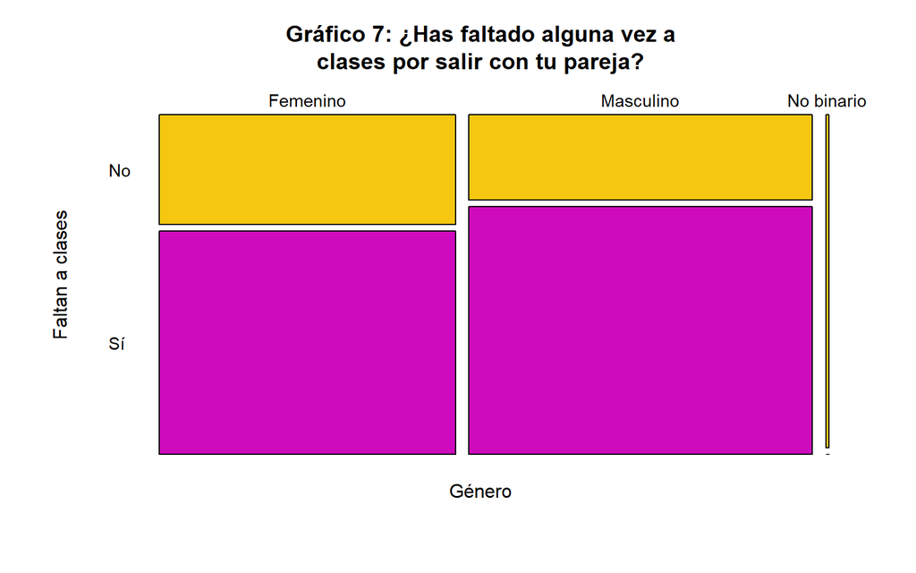

#### **Gráfico de mosaico 3**

El rendimiento académico de estudiantes tanto femenino y como masculino se ve afectado luego de una ruptura amorosa. También no hay gran diferencia entre la cantidad de estudiantes tanto femeninos y masculinos que les haya afectado el rendimiento académico. Lo que interpretamos es que el género del estudiante no influye en si le afecta académicamente una ruptura amorosa.

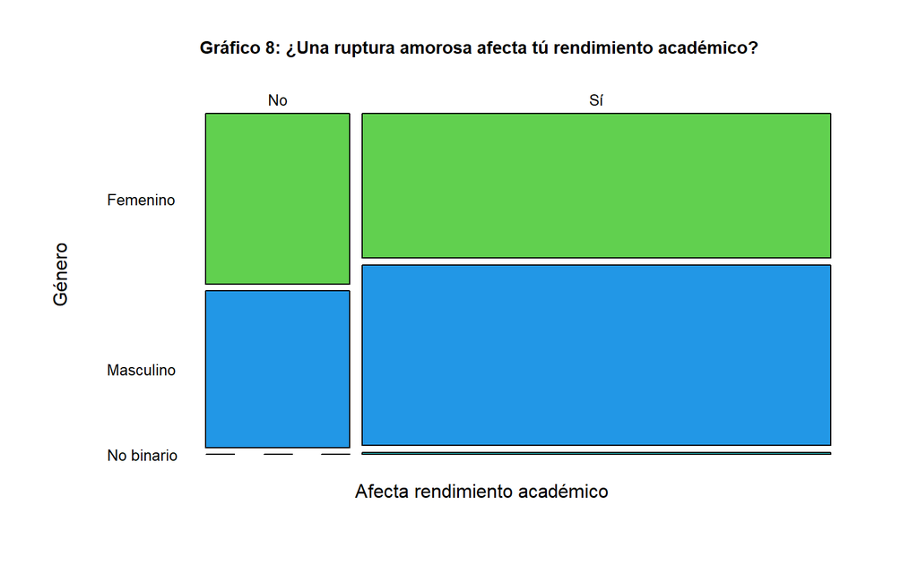

#### **Gráfico de cajas 1**

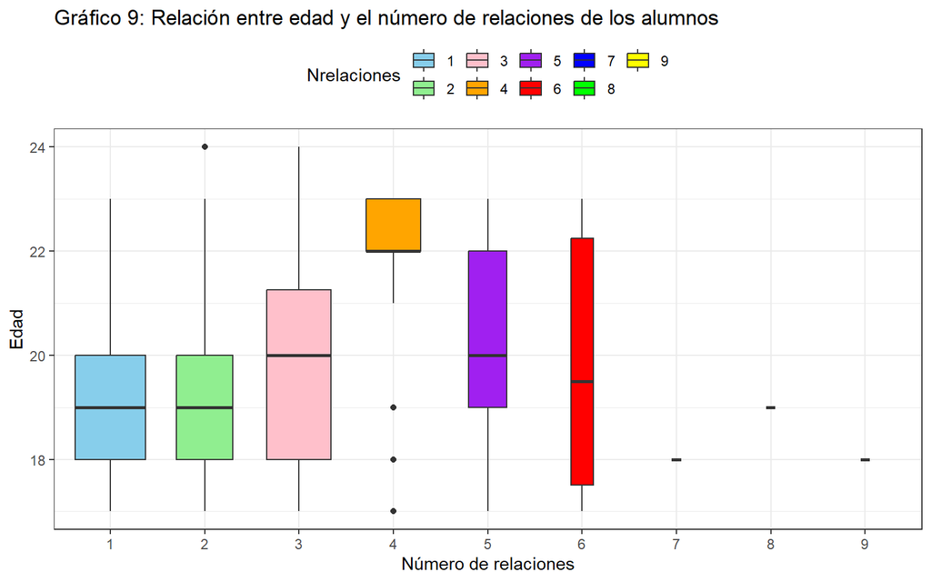

#### **Gráfico de barras 3**

- Un 35.29% de los encuestados de la muestra pertenecen al 2do ciclo.
- El 0.98% de los encuestados son de noveno ciclo.

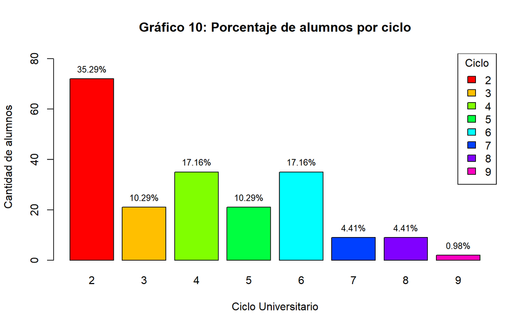

#### **Gráfico plot 2**

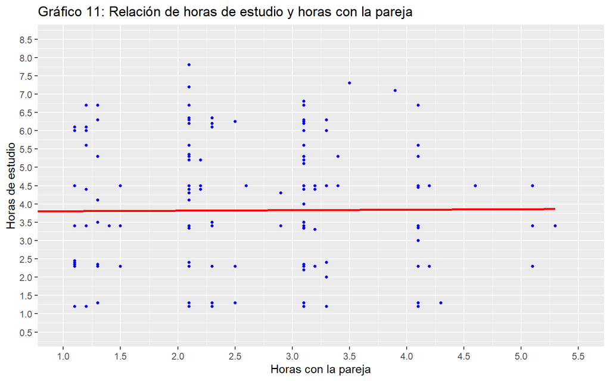

#### **Gráfico barras 4**

- Hay más encuestados de la carrera de ingeniería industrial.
- Tan solo hay 2 estudiantes de la carrera de ingeniería mecánica.

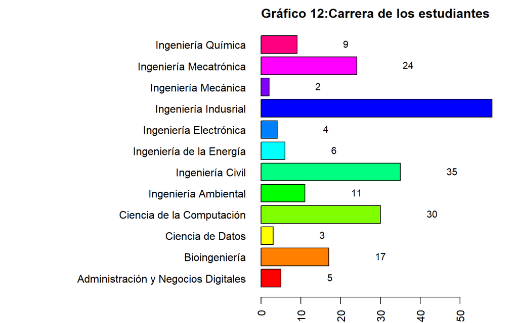

#### **Gráfico mosaico 4**

El género masculino como el femenino mayormente se distraen en el móvil o en algún otro dispositivo esperando o respondiendo un mensaje de su pareja mientras están en clase.

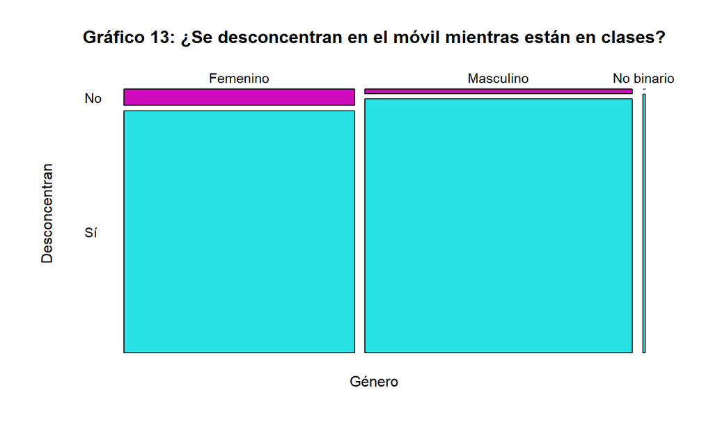

#### **Gráfico de barras 5**

62 alumnos creen que su nivel de vida amorosa esta en 4 [0-10] y de esto inferimos que no tienen una buena relación con su pareja. De 204 estudiantes solo 8 de ellos consideran que les va extremadamente bien en su relación amorosa.

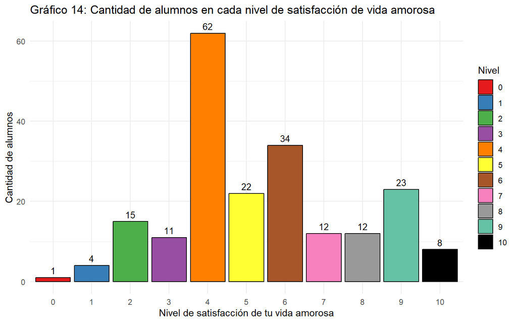

#### **Gráfico de histograma 1**

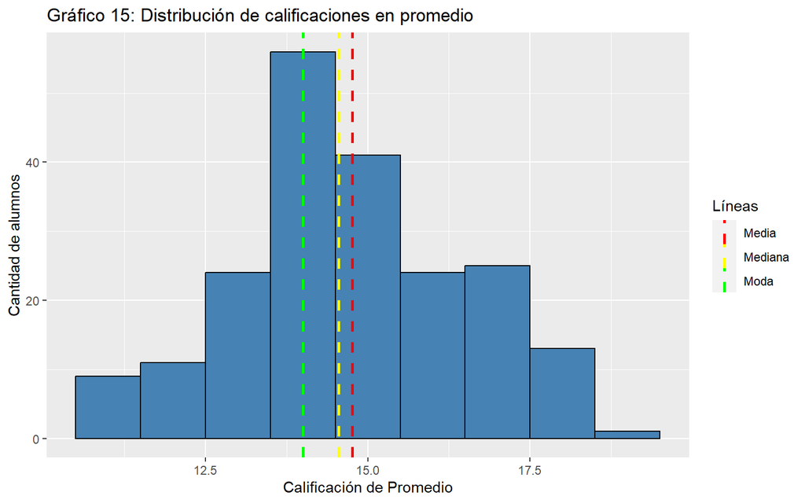

#### **Gráfico de histograma 2**

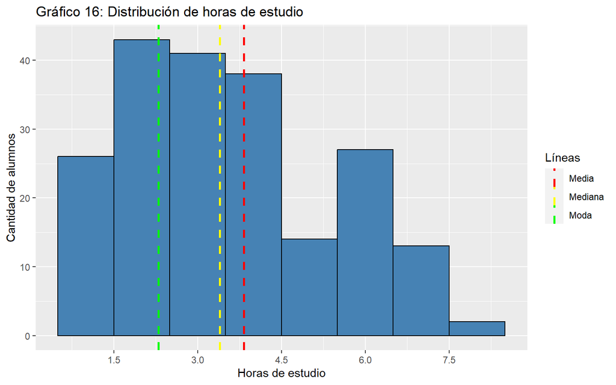

#### **Gráfico de histograma 3**

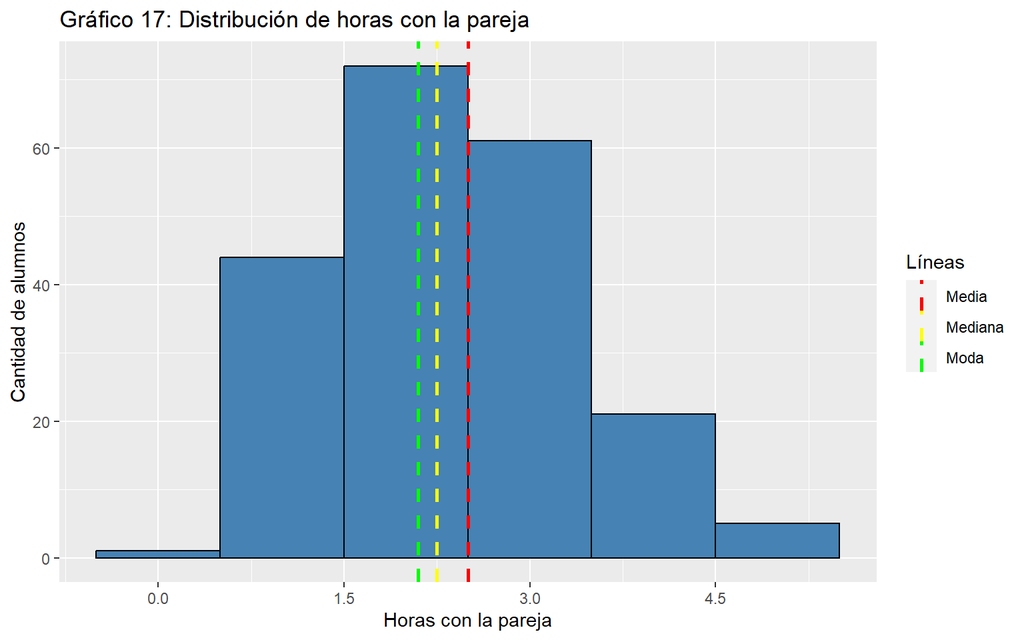

#### **Gráfico de barras 6**

- Los alumnos de la carrera de Ingeniería civil son los que tuvieron mayor número de relaciones.
- Los de la carrera de ingeniería mecánica y administración y negocios digitales tuvieron menos cantidad de parejas.

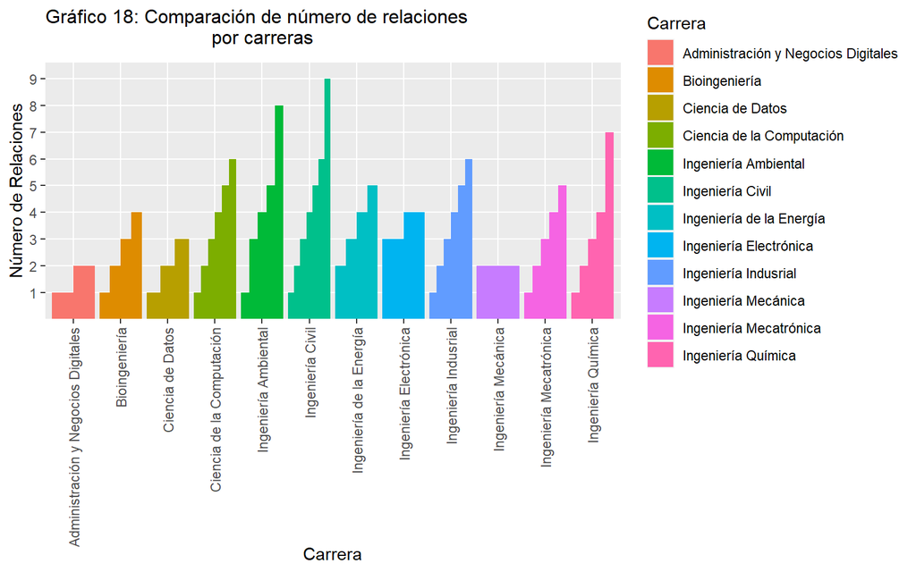

#### **Gráfico de mapa de calor 1**

- Este mapa de calor nos ayuda a identificar patrones y relaciones entre las variables estudiadas. En este caso comparando “HEstudio”, “HPareja”, “Promedio” y “Edad”. Por ejemplo, en la parte central las celdas transversales de colores más oscuros en el gráfico, indican una correlación positiva fuerte entre esas variables. Siendo estas las que tienen correspondencia consigo mismas. Por el contrario, las celdas de colores más claros o blancos, indican una correlación débil. Siendo las más claras Edad-Promedio y viceversa.

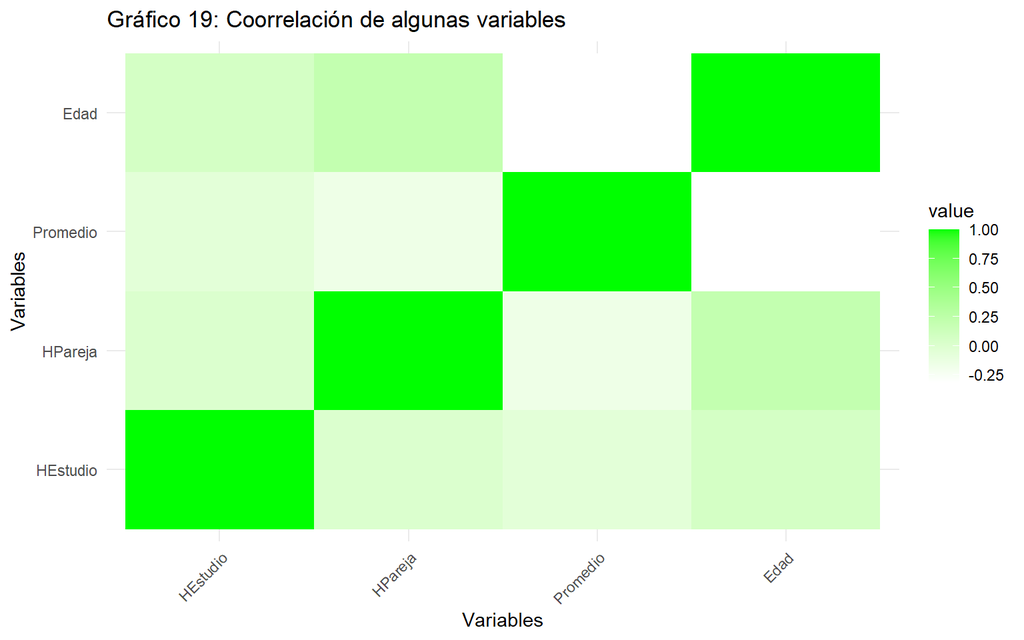